# Data Journalism

Stat 365: Statistical Communication

## Monday, April 10th

Today we will…<sup>1</sup>

- Journalistic Structure
- Data Journalism
- Diagramming Articles
[^1]: Material for today’s lecture is from [Amelia McNamara](https://www.amelia.mn/STAT336/index.html)

# Journalistic Structure

## What is journalism?<sup>1</sup>

The “fourth estate” (the other three being “the clergy, the nobility, and the commoners)

1. Journalism’s first obligation is to the truth
2. It’s first loyalty is to citizens
3. Its essence is a discipline of verification
4. Its practitioners must maintain independence from those they cover
5. It must serve as a monitor of power
[^2]: The Elements of Journalism, Bill Kovach and Tom Rosenstiel

## What is journalism?<sup>1</sup>

6. It must provide a forum for public criticism and compromise
7. It must strive to make the significant interesting and relevant
8. It must present the news in a way that is comprehensive and proportional
9. Its practitioners have an obligation to exercise their personal conscience
10. Citizens have rights and responsibilities when it comes to the news as well—even more so as they become producers and editors themselves
[^3]: The Elements of Journalism, Bill Kovach and Tom Rosenstiel

## The “inverted pyramid”

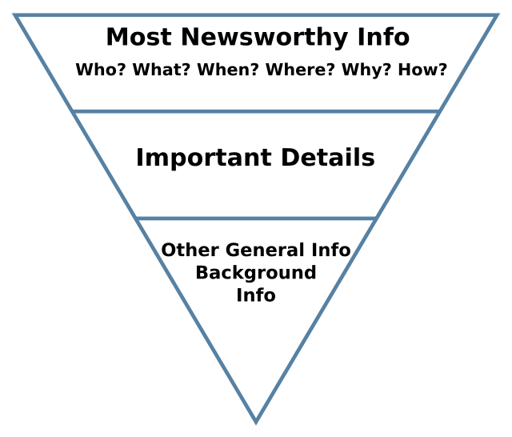

## Elements of an article<sup>1</sup>

- Headline
- Byline
- Intro/lede (sometimes spelled lead)
  - Summary intro: The 5 Ws: Who? What? When? Where? Why?
  - Wrap intro
  - Analysis intro
  - Feature intro
- Nut graphs (sometimes spelled nut grafs)
  - The “so what”
- Kicker
[^4]: https://www.reutersagency.com/en/about/standards-values/#Basic_story_structure

## The Five W’s<sup>1</sup>

| W | Question |
| --- | --- |
| *Who* | Who are the researchers investigating the problem and conducting the analysis? |
| *When* | When was the analysis carried out (e.g. “today”, “this week”, “recently”). |
| *Where* | Where was the analysis carried out? |
| *What* | What were the findings from the analysis? |
| *Why* | Why are the findings important? |

| *Who* | Who are the subjects of the study? |
| --- | --- |
| *When* | When were the data collected? |
| *Where* | Where were the data collected? |

[^5]: Communicating with Data by Nolan and Soudt

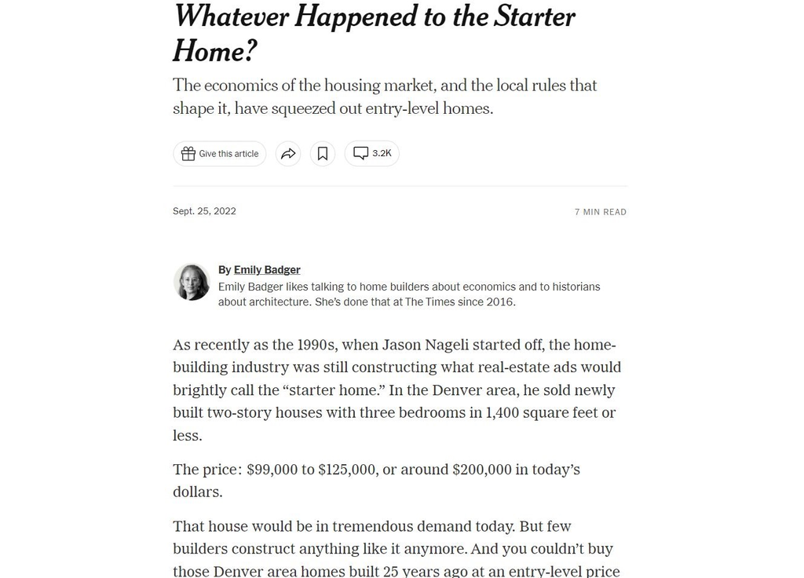

# What is “data journalism”?

> [#newsrw](https://twitter.com/hashtag/newsrw?src=hash&ref_src=twsrc%5Etfw) whether data journalism is journalism reminds when we argued about whether digital was real photography

> — rondiorio (@rondiorio) [May 27, 2011](https://twitter.com/rondiorio/status/74050318903676928?ref_src=twsrc%5Etfw)

> [@Raoldroyd](https://twitter.com/Raoldroyd?ref_src=twsrc%5Etfw) - “Data Journalism is journalism and every journalist should be a data journalist” [#CityMSddj](https://twitter.com/hashtag/CityMSddj?src=hash&ref_src=twsrc%5Etfw)

> — Interhacktives (@Interhacktives) [November 9, 2017](https://twitter.com/Interhacktives/status/928696491618832384?ref_src=twsrc%5Etfw)

- Transparency, Interactivity, Diversity, and Information Provenance in Everyday Data Journalism. Rodrigo Zamith, 2019

A smaller set of scholars have distinguished data journalism through **the form of its content.** For example, Knight (2015, p. 59) defines it as “**a story whose primary source or ‘peg’ is numeric** (rather than anecdotal), or a story which contains a substantial element of data or visualisation.” Lee and colleagues (2015, p. 85) define a ‘visual data story’ as one that includes “a set of … specific facts backed up by data” that “are visualized to support one or more intended messages” and “presented in a meaningful order.” Regardless of whether data journalism is conceptualized through form or process, two elements stand out: **(1) quantitative information should play a central role in the development or telling of the story; and (2) there should be some visual representation of the data referenced in the story.** These elements are not self-evident, however, and are difficult to operationalize. For example, how might one quantify the extent to which data influenced the generation of a story described primarily through anecdotes?

- Transparency, Interactivity, Diversity, and Information Provenance in Everyday Data Journalism. Rodrigo Zamith, 2019

## Your turn!

Pick an article to analyze the structure of

- Look for the elements we talked about (The five W’s?)
- What tips from Numbers in the Newsroom ch. 1 does the article follow?
- Does it use the inverted pyramid?
- Do you think it is data journalism?

**Some Article Ideas:**

- Baseball Opening Pitch Clock
- Gas Prices
- Alcohol Health Effects
- Black Turnout in Midterm Elections

Or, pick something else you’re interested in!

## To do

**Install word/excel**

- For class Wednesday
- Visit [Cal Poly’s Software Hub](https://tech.calpoly.edu/services/software-downloads)
- (Optional) Access via Cal Poly Virtual Computer Labs

**Formal Protocol**

- Due Thursday, 4/13 at 11:59pm

**Peer Review of Formal Protocol**